# SNA lab 2

Author

Alexandra Rottenkolber

Published

January 28, 2026

# 0 Content of this lab: Basics of Social Network Analysis

1. Add on to Friday’s lab
- Show how to fix positions of nodes in a visualisation
2. Macro-level network descriptives
- node count, edge count
- Average degree, average in-degree, average out-degree
- degree distributions –> see exercise section
- density, reciprocity, transitivity
- Shortest Path-Lengths
3. Micro-level network descriptive: centrality measures
- degree centrality
- closeness centrality
- betweenness centrality
- PageRank
4. Meso-level Homophily & Assortativity
- The qualitative case: EI-Score, assortativity
- The quantitative case: assortativity
5. Exercises

# 1 Add on to Friday’s lab

### 1.0.1 How to fix the position of nodes when plotting

[figure not shown]

```r
# read in data from last week and make graph object
edges_t1 <- read.csv("../session_1/s50_data/s50-network1.dat", header = FALSE, sep = " ") # adjacency matrix of the student network
edges_t1$V1 <- NULL # remove index
mtx <- as.matrix(edges_t1)
grph <- graph_from_adjacency_matrix(mtx)

# plot network twice, fix node position
pos = layout_with_kk(grph)
par(mfrow=c(1,2)) # Two plots side to side
plot(grph,
     main='First round',
     layout = pos) # fix position
plot(grph,
     main='Second round',
     layout = pos) # fix position
```

```r
par(mfrow=c(1,1))
```

By specifying the layout argument with the same set of positions for both plots, we can make sure that nodes do not change position.

# 2 Topological descriptives (macro level)

## 2.1 The very basics: Size and degree-measures

Where one usually starts when trying to learn someting about a network is by looking at the number of nodes and edges. They can be accessed in different ways, for example via `length(V(grph))` or `vcount(grph)` for the node count, and `length(E(grph))` or `ecount(grph)` for the edge count.

One of the most basic properties of a node is its degree, which describes the number of links attached to a node. For undirected networks, the degree is defined as the sum over a row or a column of the adjacency matrix (which is equivalent due to the adjecency martix being symmetric for undirected graphs). For directed networks, the measure is defined a bit more nuanced: Here, we distingustish between the in-degree (number of incoming edges), and out-degree (number of outgoing links). We will look into this in more detail in the exercises (there I will also show you the respective formulas, too). The degree-measures can be further extended for weigted graphs. For weigted graphs, we talk about the strength, s, of a node, which is the sum of the weights of the edges attached to a node (for undirected graphs), as well as about the in-strength and out-strength for directed graphs.

Let’s look at some real world data: The data set we will use now contains the e-mail network of a large European research institution. The information was anonymized and published together with [this paper](https://cs.stanford.edu/people/jure/pubs/mappr-kdd17.pdf). An edge exists between two persons if one send the other at least one e-mail (does not have to be reciprocal). The network contains only communication within the institution (no out-going interactions).

```r
# load data + some preparation
df <- read.csv("../session_2/data/email-Eu-core.txt", header = FALSE, sep = " ") # edge list
df$V1 <- df$V1+1 # a node ID of 0 is not allowed, we increase every ID by 1
df$V2 <- df$V2+1 # a node ID of 0 is not allowed, we increade every ID by 1
df_mtx <- as.matrix(df)
G_eu <- graph_from_edgelist(df_mtx)
```

```r
# First basic descriptives: node count, edge count, directed?

## count nodes
length(V(G_eu)) # 1005
```

```
[1] 1005
```

```r
vcount(G_eu)
```

```
[1] 1005
```

```r
# count edges
length(E(G_eu)) # 25571
```

```
[1] 25571
```

```r
ecount(G_eu)
```

```
[1] 25571
```

```r
# directed?
is_directed(G_eu) # yes
```

```
[1] TRUE
```

Let’s look at the average degree, average in-degree, and average out-degree. What changes when we convert the directed graph into an undirected one?

```r
# Average degree
avg_degree <- mean(igraph::degree(G_eu))
avg_in_degree <- mean(igraph::degree(G_eu, mode = "in"))
avg_out_degree <- mean(igraph::degree(G_eu, mode = "out"))
cat("The average degree is:", round(avg_degree, 2),"\n",
    "The average in-degree is:", round(avg_in_degree, 2), "\n",
    "The average out-degree is:", round(avg_out_degree, 2), "\n")
```

```
The average degree is: 50.89
 The average in-degree is: 25.44
 The average out-degree is: 25.44
```

```r
# Standard deviations
sd(igraph::degree(G_eu, mode='out'))
```

```
[1] 33.32393
```

```r
sd(igraph::degree(G_eu, mode='in'))
```

```
[1] 27.97082
```

```r
# Range
range(igraph::degree(G_eu, mode='out'))
```

```
[1]   0 334
```

```r
range(igraph::degree(G_eu, mode='in'))
```

```
[1]   0 212
```

```r
# Make the graph symmetric (convert to an undirected graph)
uG_eu <- as.undirected(G_eu, mode = "collapse")

# Average degree for the undirected graph
avg_degree_unsymmetric <- mean(degree(G_eu))

# Average degree for the symmetric graph
avg_degree_symmetric <- mean(degree(uG_eu))
cat("After making the network symmetric, the average degree is:",
    round(avg_degree_symmetric, 2), "\n")
```

```
After making the network symmetric, the average degree is: 33.25
```

*Questions to you:*

- Why is the average in- and out-degree the same?
- Do you have an intuition for why the average degree for the directed graph is ~51, and for the symmetric one only ~33? What happened?

*Your answer:*

## 2.2 Density, reciprocity and degree measures.

```r
# Density
igraph::edge_density(G_eu) # you can also report it as a percentage, density is sensitive to size
```

```
[1] 0.02534241
```

```r
# Reciprocity
igraph::reciprocity(G_eu) # in igraph, reciprocity is edgewise by default
```

```
[1] 0.7112199
```

```r
sna::grecip(as.matrix(as_adjacency_matrix(G_eu)), measure = "edgewise") #measure = c("dyadic", "dyadic.nonnull", "edgewise", "edgewise.lrr", "correlation")) # check definition of other reciprocity specifications
```

```
      Mut
0.7112199
```

```r
# Transitivity (= clustering coefficient)
# Captures triangles; how many of existing triads (e.g. relationships) are actually closed
igraph::transitivity(G_eu)
```

```
[1] 0.2673924
```

```r
# can also be calculated at the node-level
```

## 2.3 Components strong and weak

In network-science language, a connected sub-graph – if it is not part of any larger sub-graph, and undirected – is called a *component* (or sometimes *connected component*).

For directed networks, the terminology has to be (again) a little more nuanced. Here, *weakly connected compnents* and *strongly connected components* are distinguished from each other. Let’s look at an example. We have the following directed graph:

```
(a) --> (b) <--> (c) <-- (d)   (e)
```

If we ignore the direction of the edges, we can walk from $a$ to $d$ without any problem. Reaching $e$, however, is not possible. Hence, $a$, $b$, $c$, and $d$ constitute a connected component, which we have to call *weak* as we ignored the direction of the edges.

Starting at $b$ and taking the direction of the edges into account, it is possible to reach $c$, but neither $d$, $a$, or $e$. $b$ and $c$ together hence build a *strongly connected component*.

For convenience, people often start working with the largest sub-graph of a network. This sub-graph is called the *largest connected component*, and – if it contains more than 50% of all nodes – it deserves the name *giant component*. In real-world networks, the *giant component* contains often more than 95% of all nodes, which means that one can learn already a lot by only examining this component.

```r
# Number of strongly connected components
scc <- igraph::components(G_eu, mode = "strong")
num_scc <- scc$no

no_max_scc <- max(scc$csize) # largest one
no_min_scc <- min(scc$csize) # smallest one

scc$csize[scc$csize > 1] # only components that have more than 1 member
```

```
[1] 803
```

```r
cat(glue("For the EU-core network, we observe {num_scc} strongly connected components, of which the largest one contains {no_max_scc} nodes, and the smallest one {no_min_scc}."))
```

```
For the EU-core network, we observe 203 strongly connected components, of which the largest one contains 803 nodes, and the smallest one 1.
```

```r
# Number of weakly connected components
wcc <- igraph::components(G_eu, mode = "weak")
num_wcc <- wcc$no

# size of components
no_max_scc <- max(wcc$csize) # largest one
no_min_wcc <- min(wcc$csize) # smallest one

wcc$csize[wcc$csize > 1] # only components that have more than 1 member
```

```
[1] 986
```

```r
cat(glue("For the EU-core network, we observe {num_wcc} weakly connected components, of which the largest one contains {no_max_scc} nodes, and the smallest one {no_min_wcc}."))
```

```
For the EU-core network, we observe 20 weakly connected components, of which the largest one contains 986 nodes, and the smallest one 1.
```

*Questions to you:*

- What can you infer from the number of strongly and weakly connected components? (Keep in mind that we are looking at an e-mail network (who wrote whom).)
- What does it mean that the smallest component contains only one node?

*Your answer:*

*FYI.* A very usful technique that is sometimes used instead of looking at the largest connected component is called k-core decomposition (You do not need to worry about this now. I am just mentioning it so that you know it exists and have an idea for when it can be helpful). The objective of that method is to disentangle the hierarchical structure of networks by extracting – step by step – more densly connected central cores. It can, for example, help to find the most important/most relevant sub-unit/core that is not necessarily a component itself (as it is probably smaller). If you want you can ask me in the Lab session and I can explain a bit more. For our e-mail network, we could use it to find the core of best connected people, instead of looking at the largest “clique” (component).

# 3 Centralities and position-based metrics

Which are the important nodes? Ranking nodes by their importance is a rather non-trivial task. If we have no better idea, we could start by looking at degrees, and conclude that the nodes with the most links are likely to be the most important ones. By taking this approch, however, we might miss important information. What, for example, if a node bridges two communities, and if this particular node was gone, there was no connection left between them? Such a node has probably a very small degree (maybe 2), but is extremely important for the a networks’ topological characteristics (citical for example for information flow, exchange, exposure, etc.). Network scientists acknowledged this problem, too, and developed different metrices (usually summarised as centrality measures) to cover these specialities. In this exercise, we will take a look at a few examples. But first, some important terms:

## 3.1 Some terminology: Random walk, path, shortest path, diameter

*Random walk*: A walk from one node to another one by which the choice of nodes that are passed in between is random.

*Path*: Walk where all nodes visited are distinct.

*Shortest path*: Of all the paths that connect two nodes, the shortest one (in terms of how many nodes are passed/how many edges crossed). Often used in social network analyis to examine information flow. For directed networks: A shortest path must respect the direction of its edges.

*Diameter*: Number of edges in the longest of all shortest paths present in a network.

## 3.2 The shortest path

Knowing the length distribution of all shortest paths in a network can tell us a lot about a networks connectivity. A narrow distribution implies that all nodes are somewhat equally connected to each other (or: more or less equally far apart from the average node of a network). A spread out disrtibution, however, can indicate that some nodes are far out in the periphery, whereas others build a densly connected core.

For this part, we are not interested in the direction of edges but only in the fact, whether a connection exists or not (i.e. we can work with the undirected graph). (We can hypothesise that, if you received an e-mail from a person, but did not answer it, you are still connected to them in the way that you have each others contact infromation. This is also true for the opposite case).

```r
# Calculate shortest paths from a specific node (e.g., node 1)
shortest_paths_from_1 <- shortest_paths(uG_eu, from = 1)
#print(shortest_paths_from_1$vpath)

# Calculate the shortest path between two specific nodes (e.g., 1 and 100)
shortest_path_1_to_100 <- shortest_paths(uG_eu, from = 1, to = 100)
#print(shortest_path_1_to_100$vpath)

# Calculate all-pairs shortest paths
shortest_paths_mtx <- distances(uG_eu) # Computes the lengths of shortest paths between all pairs of nodes in the graph. Returns a matrix where the entry [i, j] is the shortest path distance between nodes i and j.
```

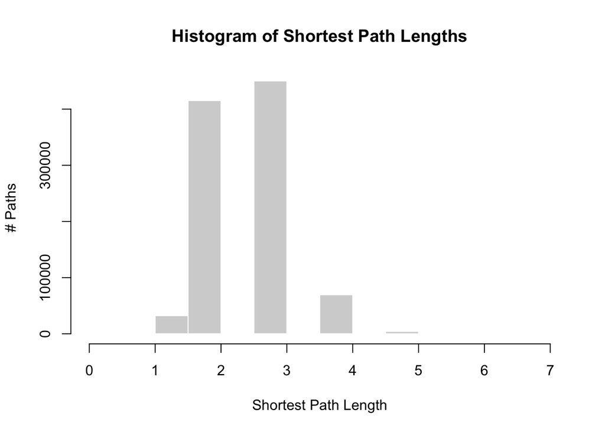

```r
# Flatten the distance matrix into a vector and remove self-loops (distance = 0)
shortest_path_lengths <- as.vector(shortest_paths_mtx[shortest_paths_mtx > 0])

# Plot a histogram of shortest path lengths
hist(shortest_path_lengths,
     main = "Histogram of Shortest Path Lengths",
     xlab = "Shortest Path Length",
     ylab = "# Paths",
     xlim = c(0, 7),
     border = "white")
```

Usually, paths length are roughly normally distributed (something like the classical bell shape). This is also the case for our network.

Most likely, you have already heard of the “[six degrees of separation](https://www.theguardian.com/technology/2008/aug/03/internet.email)” or the “six handshake rule” which is thought to describe “social distance”. It states that – on average – two people are only six steps apart from each other. Let’s use what we have just learned to investigate how large the average degree of separation is for our network (how many edges are on average between node $v_i$ and $v_j$):

```r
# Get largest connected component
largest_component <- which.max(scc$csize)

# Create a subgraph containing only the largest connected component
largest_scc <- induced_subgraph(uG_eu, which(scc$membership == largest_component))

avg_path_length <- mean_distance(largest_scc, directed = FALSE, unconnected = FALSE)
cat(glue("Our network has {round(avg_path_length, 2)} degrees of separation."))
```

```
Our network has 2.37 degrees of separation.
```

**Questions to you:** - Do you have an intuition for why we looked at the largest strongly connected component, and not at the weakly one?

**Your answer:**

## 3.3 Closeness Centrality

Closeness centrality can be thought of as a reachability measure. The score is normalised. 1 means that all nodes which are reachable are so directly (other words: if every node is directly connected to node $v$, then $v$’s centrality score would be 1). A score below 1 indicates that paths are less direct.

In mathematical terms, the closeness centrality (for node $v$) can be expressed as :

$$C(v) = \frac{|V| - 1}{\sum_{u} |P_{vu}|} \left( = \frac{1}{\text{Average Path Length}_{v}} \right) = \text{distance}^{-1}$$

with $|P_{vu}|$: length to go from $v$ to $u$;

$|V| - 1$: the number of all possible destination in a network if one starts from $u$, which is equal to the number of nodes minus 1.

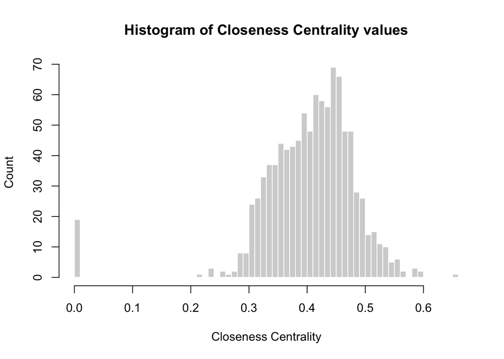

```r
cc_igraph <- igraph::closeness(largest_scc, mode = "in") # here we get NANs for those nodes which are isolates
cc_sna <- sna::closeness(as.matrix(as_adjacency_matrix(uG_eu)), cmode="suminvundir") # alternative we can take an approach suggested by Gil and Schmidt (1996), available via the SNA packages, that allows the graph to be disconnected. Use cmode="suminvdir" for a directed graph
hist(cc_sna,
     main = "Histogram of Closeness Centrality values",
     xlab = "Closeness Centrality",
     ylab = "Count",
     breaks = 50,
     border = "white")
```

**Questions to you:**

- Interpret the distribution. What do you see and how can it be interpreted?

**Your answer:**

## 3.4 Betweenness Centrality

Betweenness centrality and closeness centrality have some commonalities. Both are distance-related measures, characterising a node’s position in the entire network. While the closeness centralitiy of a node can be thought of as a measure for “reachability”, a node’s betweenness centrality is an indication of how much nodes act as “intermediaries”.

$$C_B(v) =\sum_{s,t \in V} \frac{\sigma(s, t|v)}{\sigma(s, t)}$$

where $V$ is the set of nodes;

$\sigma(s, t)$ is the number of shortest $(s, t)$-paths;

and $\sigma(s, t|v)$ is the number of those paths passing through node $v$ other than $s, t$.

If $s = t$, $\sigma(s, t) = 1$, and if $v \in {s, t}$, $\sigma(s, t|v) = 0$.

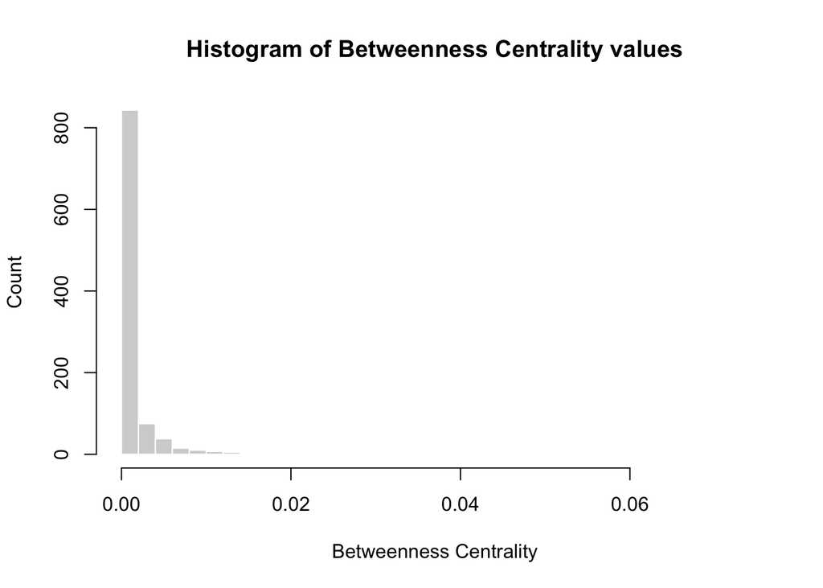

```r
bc_sna <- sna::betweenness(as.matrix(as_adjacency_matrix(G_eu)), cmode="directed", gmode="digraph")
bc_igraph <- igraph::betweenness(G_eu, directed = TRUE,  weights = NULL,  normalized = TRUE)
hist(bc_igraph,
     breaks = 50,
     main = "Histogram of Betweenness Centrality values",
     xlab = "Betweenness Centrality",
     ylab = "Count",
     border = "white")
```

```r
max(bc_igraph)
```

```
[1] 0.07212079
```

**Questions to you:** - Interpret the distribution. What do you see and how can it be interpreted?

**Your answer:**

**Comment.** Centrality functions use the shortest path lengths and are hence sensitive to the direction of edges in directed graphs.

## 3.5 PageRank

PageRank was invented by Google in 1988 to rank webpages by their importance for their search engine (It’s desinged for directed graphs). PageRank became extreamly famous as it solved a the problem that for networks that are not fully connected, i.e. consists of several components, it was not possible to calulate one ranking for the whole graph. Rather one got several rankings: One for each component. To solve that issue, Google founders Larry Page and Sergei Brin had a very smart – and almost embarrassingly easy to implement – idea: They wanted a random walker traversing though their graph to be able to hop between components. They implemented it by assigning a tiny probability to a “teleportation to another component” option to every step in the random walk. This idea is equivalent to adding very weak edges (edges having a very small weight) connecting all components. The damping factor $\alpha$ in the PageRank calucation (see code below) is defined as one minus the “teleportation probability”.

Damping factor: $\alpha = 1-\epsilon$, with $\epsilon$ can be thought of the “teleportation parameter”/probability of a jump.

If $\epsilon = 0$ PageRank becomes the degree.

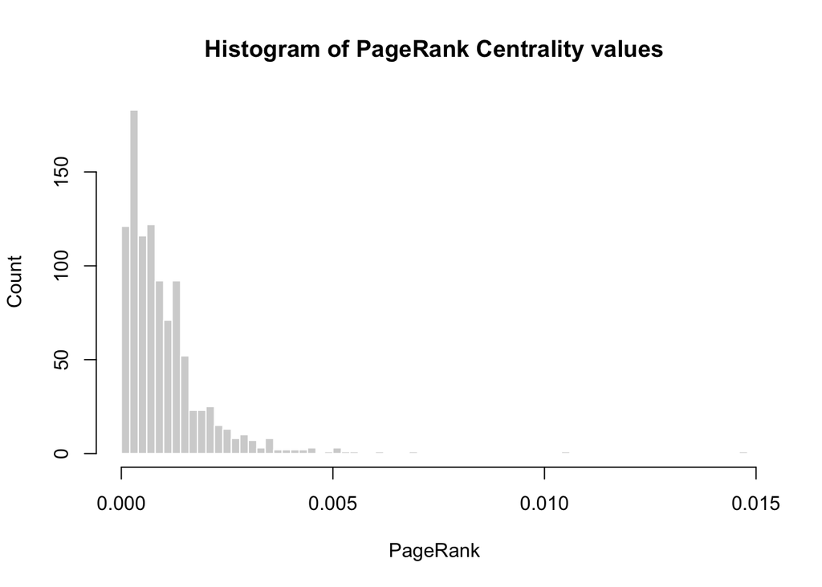

```r
pr <- igraph::page_rank(G_eu, damping = 0.9, algo = "arpack")$vector
hist(pr,
     main = "Histogram of PageRank Centrality values",
     xlab = "PageRank",
     ylab = "Count",
     breaks = 100,
     border = "white")
```

```r
min(pr)
```

```
[1] 0.0001286984
```

```r
sum(pr)
```

```
[1] 1
```

**FYI.** There are many more node-ranking algorithms around that are alternatives to the ones shown above (Eigenvector centrality is similiar to PageRank for example), or measure slightly different characteristics (Katz, Reach). They are nicely summarised [here](https://www.networkatlas.eu/files/sna_book.pdf), Chapter 11.

**Comment.** With networks it is always the same: By now, there are a multitude of options, approaches and measures out there, but finding the right tool (centrality measure, etc…) for the job you want to so, is always one of the main tasks and requires a bit of exploring, understanding your research question well, and deciding upon the optimal strategy.

# 4 Homophily & Assortativity

*– This is about sorting of nodes based on attributes –*

or “birds of the same feather flock together”.

In social networks, homophily implies that nodes of a similar kind connect with each other ([famous paper with regard to homophily in Social Networks](https://www.annualreviews.org/doi/10.1146/annurev.soc.27.1.415)).

It is, however, important to keep in mind that there are many factors which can influence homophily and not all of them are driven by individual preferences: In some cases, homophilic clustering might also emerge from constrained access. It might be the case that people group together not because they dislike others who are different but simply because they do not have access to the other group. Sometimes, it might also be the case that observed patterns are driven by a combination of preferences and access. The exact mechanism, however, is nothing that can be inferred from looking at a network’s mesostructure only. Usually, a deeper investigation is required for that.

## 4.1 Quantifying homophily: EI index, assortativity index

What would be really helpful is to have an objective way of quantifying the extent to which homophily is driving a network’s connections. There are two different ways to measure homophily, depending on whether node attributes are qualitative or quantitative.

### 4.1.1 The qualitative case: EI index, qualitative assortativity index

*EI score*. One approach sometimes used is called the EI score. It gives an idea of how “in-grouped” a network is and reads in mathematics terms:

$$EI = \frac{(\text{Number of external links} - {\text{Number of internal links}})} {(\text{Number of external links} + \text{Number of internal links})}$$

The EI score takes -1 if there is perfect homophily and +1 if there is perfect heterophily.

This approach, however, has severe shortcomings, as it does not work well if there are more than 2 groups and if groups are of different sizes.

If this were to be the case, we need a more advanced measure:

*Qualitative assortativity*. The assortativity coefficient $r$ describes the probability of edges “connecting alike nodes per attribute value *i* […][compared] to the probability of an edge to have at least one node with attribute value *i*” ([Coscia (2021)](https://www.networkatlas.eu/), p. 369). ([Paper](https://arxiv.org/pdf/cond-mat/0209450.pdf) introducing the assortativity coefficient. This is also what igraph returns if you envoke `assortativity_nominal(graph, types)`).

$$r = \frac{\sum_i e_{ii} - \sum_i a_i b_i}{1 - \sum_i a_i b_i},$$

with $e_{ii}$ as the probability of an edge to connect to nodes of similiar kind (i.e. with attribute value $i$), $a_i$ is the probability that an edge has a node with attribute $i$ as source, and $b_i$ is the probability that an edge has a node with attribute $i$ as target. For an undirected network, $a_i = b_i$. The assortativity coefficient $r$ can be interpreted similar to Pearson correlation coefficients. $r$ is 1 if there is perfect assortativity and -1 if there is perfect disassortativity.

Figure 2 illustrates what each part of the formula means.

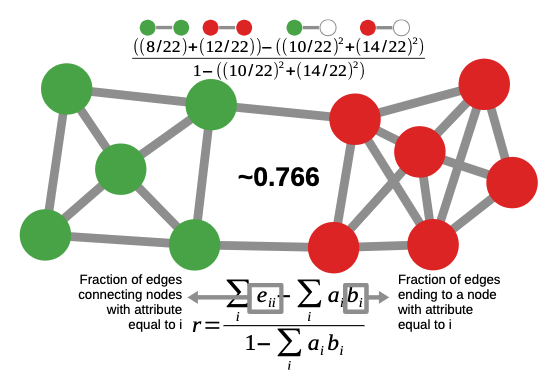

**Figure 2: Calculation of the assortativity coefficient** (taken from [Coscia (2021)](https://www.networkatlas.eu/), p. 370).

## 4.2 The quantitative case: quantitative assortativity index

*Edge-centric approach* For the first one, the approach is to iterate over all edges and to create two vectors which contain the attribute, e.g. the degree/age/…, of the two endpoints for every edge. For undirected networks, every edge contributes two entries to every vector. The assortativity reported is simply the Pearson correlation coefficient of these two vectors. This is the one implemented in the igraph package.

*Node-centric approach*. For the second one, the approach is to fit the average attributes of the nodes’ neighbours against the attribute of the nodes themselves. (Often the data needs to be log-transformed and power-fitted, e.g. for the degree assortativity!). The exponent of such a fit tells whether a network is assortative (exponent is positive), or disassortative (exponent is negative), or non-assortative (exponent is zero). (Not further investigated in this lab, just included for completeness.)

## 4.3 Let’s look at an example:

```r
# A friendship network
edges_dir <- c("Elizabeth", "Cindy",
               "George", "Cindy",
               "Cindy", "David",
               "David", "Betty",
               "Betty", "Adam",
               "Cindy", "Elizabeth",
               "Fred", "Betty",
               "Cindy", "Betty",
               "Adam", "Fred",
               "Adam", "David")

# Create a undirected graph
Gu <- graph_from_edgelist(matrix(edges_dir, ncol = 2, byrow = TRUE), directed = FALSE)

# Add some attributes
V(Gu)$gender <- c("f", "f", "m", "d", "f", "m", "m")
V(Gu)$gender_num <- c(1, 1, 2, 3, 1, 2, 2)
V(Gu)$age <- c(27, 25, 22, 17, 42, 51, 48)
```

[figure not shown]

*Recap*

- EI index: -1 means perfect homophily, +1 indicates perfect heterophily (or, formulated differently: positive would mean most ties are external and negative means most ties are internal (i.e. within one group).) Note. Be careful with the EI index! It works well if we have similarly sized groups, but is a bit misleading if the groups we have groups are of substantially different sizes.
- Assortativity: Similiar to the EI score, but able to take different group sizes/more than two groups into account. 1 means perfect assortativity, -1 perfect disassortativity.

```r
# let check for our friendship network
# Careful, positive assortativity means homophily (contrary to the EI index)
?assortativity

# For categorical attributes
isnar::ei(Gu,'gender') # EI index
```

```
[1] 0.2
```

```r
isnar::assort(Gu,'gender')
```

```
[1] -0.02564103
```

```r
# how to calcualte the assortativity using the igraph package
igraph::assortativity_nominal(graph = Gu,
                              types = as.numeric(as.factor(V(Gu)$gender)),
                              directed = FALSE)
```

```
[1] -0.02564103
```

```r
# For continuous attributes
isnar::assort(Gu,'age')
```

```
[1] -0.2048193
```

```r
assortativity_degree(Gu, directed= FALSE) # degree assortativity
```

```
[1] -0.5972222
```

According to the EI value, we see a tendency for heterophily with regard to “gender”.

Assortativity helps understanding if nodes tend to connect to similar or dissimilar nodes and this network property may affect the network structure: a strong assortativity on a discrete attribute may for instance break the network into subnetworks. Here, there is some extent of disassortativity with regard to gender in the network, and a stronger one for degree.

*Comment:* **Network language.** The language one usually uses for concluding about assortative mixing is something along the lines of “this friendship network is assorted by gender” (if there is not so much mixing between genders) or “this dating network is disassorted by gender” (as empirically, the majority of couples are heterosexually formed, there is “mixing” among genders).

# 5 Exercise on centrality measures

Imagine the graph below represents a borrower & lender network, i.e. it connects people who have lent each other something (A <– B means B has borrowed from A).

Let’s imagine:

- a book is lent by
  - Elizabeth from Cindy
  - George from Cindy
  - Cindy from David
- a bike is lent by
  - David from Betty
  - Betty from Adam
- a jumper is lent by
  - Cindy from Elizabeth
  - Fred from Betty
- a game is lent by
  - Cindy from Betty
  - Adam from Fred

An undirected graph is insufficient to capture these relationships, hence we need to create a directed representation. We will call it Gd (same network as above). We will add the people’s names to the nodes as attributes and add the item that changed holder to the edges.

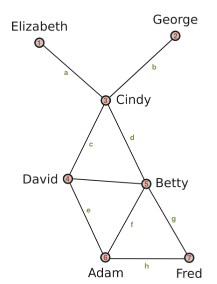

```r
# Define the edges for the directed graph
edges_dir <- c("Elizabeth", "Cindy",
               "George", "Cindy",
               "Cindy", "David",
               "David", "Betty",
               "Betty", "Adam",
               "Cindy", "Elizabeth",
               "Fred", "Betty",
               "Cindy", "Betty",
               "Adam", "Fred",
               "Adam", "David")

# Create a directed graph
Gd <- graph_from_edgelist(matrix(edges_dir, ncol = 2, byrow = TRUE), directed = TRUE)

# Add attributes for each edge (who lent what item)
E(Gd)$lent_item <- c("book", "book", "book",
                     "bike", "bike",
                     "jumper", "jumper",
                     "game", "game", "game")

E(Gd)[1]
```

```
+ 1/10 edge from bae2e78 (vertex names):
[1] Elizabeth->Cindy
```

```r
E(Gd)[1]$lent_item
```

```
[1] "book"
```

```r
# color edges based on lent item
length(unique(E(Gd)$lent_item)) # number of unique items
```

```
[1] 4
```

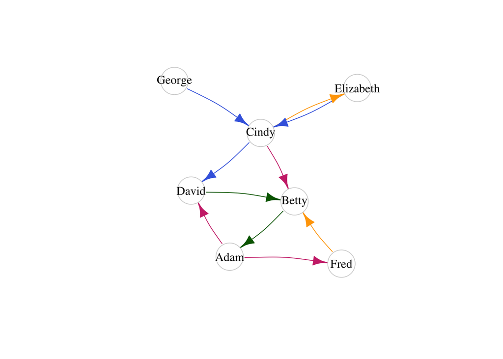

```r
lent_items <- unique(E(Gd)$lent_item) # get unique items
pal <- c("royalblue", "darkgreen", "orange", "violetred3") # select 4 colors
color_map <- setNames(pal[1:length(lent_items)], lent_items)  # Map items to colors
E(Gd)$color <- color_map[E(Gd)$lent_item] # Assign colors to edges based on the lent_item attribute

# Print information about the graph
pos = layout_with_kk(Gd)
plot(Gd,
     vertex.size= 30,
     vertex.color= "white",
     vertex.frame.color = "lightgrey",
     vertex.label.color = "black",
     edge.color=E(Gd)$color,
     layout = pos,
     edge.curved=c(rep(0.1, 19)))
```

## 5.1 Exercise 1: In- and out-degree, degree-distribution

1. Print the basics descriptives of the directed version of the borrower-lender network (*Gd*) (number of nodes and edges).

```r
# number of nodes


# number of edges
```

2. For your undirected borrowing-and-lending network,
- calculate the average degree $\langle k \rangle = \frac{1}{N} \sum_i k_i$ ($N$: number of nodes, $k_i$ degree of node $i$) and
- plot the degree distribution. What can you learn from the distribution?

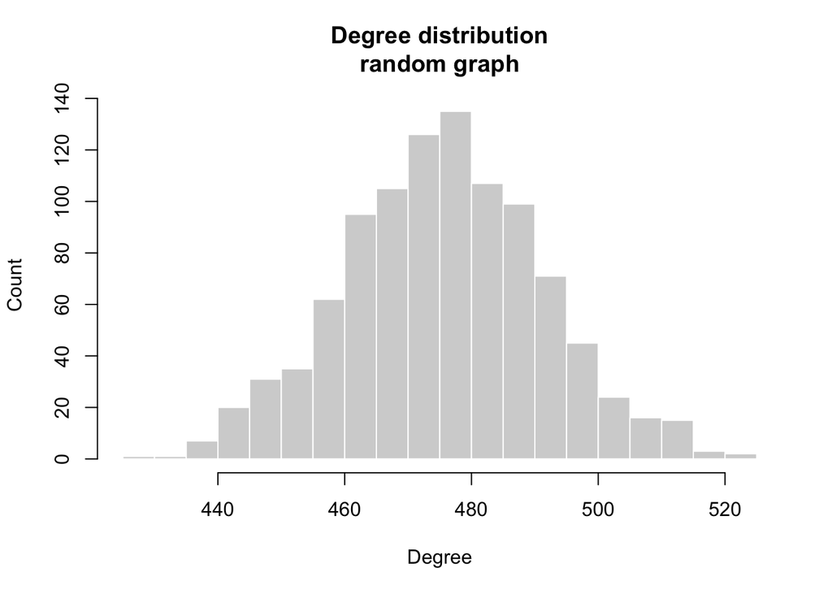

```r
# degree distribution of the lender-borrower network


# degree distribution of a random graph
hist(igraph::degree(igraph::erdos.renyi.game(n = 1000, p.or.m = igraph::edge_density(Gu))),
     main = "Degree distribution\nrandom graph",
     xlab = "Degree",
     ylab = "Count",
     breaks = 20,
     border = "white")
```

3. For your directed lender/borrower network,
- calculate the average in- and out-degree.

The in-degree of node $i$ is definded as $k_i^{in} = \sum_j A_{ij}$, with $A$ being the adjacency matrix, $i$ the target node. The out-degree of node $i$ is definded as $k_i^{out} = \sum_j A_{ji}$, with $A$ being the adjacency matrix, $i$ the source node.

- plot the in-degree and out-degree distribution. What can you learn from the distribution?

What does the average degree tell us?

*Your answer:*

*Example answer:*

## 5.2 Exercise 2: Ranking nodes – Which are the important ones?

1. Calculate the closeness centrality for the borrower-lender network. Plot the distribution. What does the pattern you see mean (undirected network will suffice)?
2. Do the same as in (a) for betweenness and PageRank (undirected network will suffice). What does the pattern you see mean?
3. Create four network visualisations in which the color of the nodes indicates the degree, closeness centrality, the betweenness centrality, and the PageRank, respectively. Have a look at the tidygraph and ggraph package to easily generate such colour-coded plots: https://ggraph.data-imaginist.com/articles/tidygraph.html

*Closeness*

*Betweenness*